# Genetyka

Agata Żbikowska

# Genetyka

### Genom ludzki:

wynosi blisko 30 000 genów oraz zawiera **46 chromosomów** w tym:

- 22 pary chromosomów autosomalnych
- 2 chromosomy płci (XX lub XY)

DNA mitochondrialne koduje 37 genów + enzymy szlaku metabolicznego komórki DNA mit jest dziedziczone po matce.

### DNA – podwójna helisa

- Struktura cząsteczki zaproponowana w 1953 przez Watsona i Cirka
- Jest prawoskrętne (zgodnie z ruchem wskazówek zegara)
- Łańcuchy położone są antyrównolegle
- Grupy fosforowe i grupy cukrowe zlokalizowane są na zewnątrz łańcucha, natomiast zasady azotowe wewnątrz helisy
- Miedzy komplementarnymi zasadami (A-T; C-G) znajdują się wiązania wodorowe
- Nukleotydy są połączone wiązaniami fosfodiestrowymi

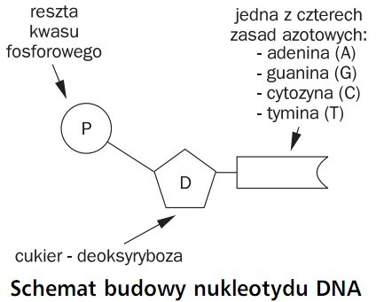

fot.1.

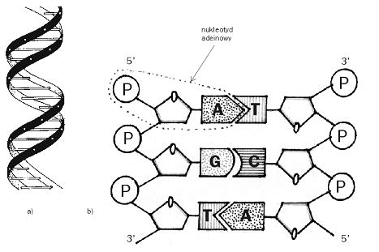

fot.2.

### RNA

- jest mało stabilną cząsteczką
- występuje uracyl zamiast tyminy
- jest głównie jednoniciowe :

**kodujące** → mRNA-(z ang. messenger RNA; RNA informacyjne), transkrypt genów które ulegają translacji do białek. Stanowi 3-5% całkowitego RNA

**niekodujące** → rRNA - (z ang. ribosomal RNA; RNA rybosomowe), buduje rybosomy tRNA - (z ang. transfer RNA; RNA transferowy, RNA transportujący), dostarcza aminokwasy do rybosomu (70 do 80 nukleotydów)

Wszystkie znane tRNA mają następujące cechy wspólne:

- Ramię antykodonowe. Rozpoznaje kodon na mRNA
- Ramię akceptorowe. Sekwencja CCA - miejsce przyłączania aminokwasu
- Ramię DHU (Dihydrouracylowe) sekwencja tu zawarta rozpoznawana jest przez enzym, który przyłącza do tRNA odpowiedni aminokwas
- Ramię TΨC (Pseudouracylowe) umożliwia przymocowanie do rybosomu

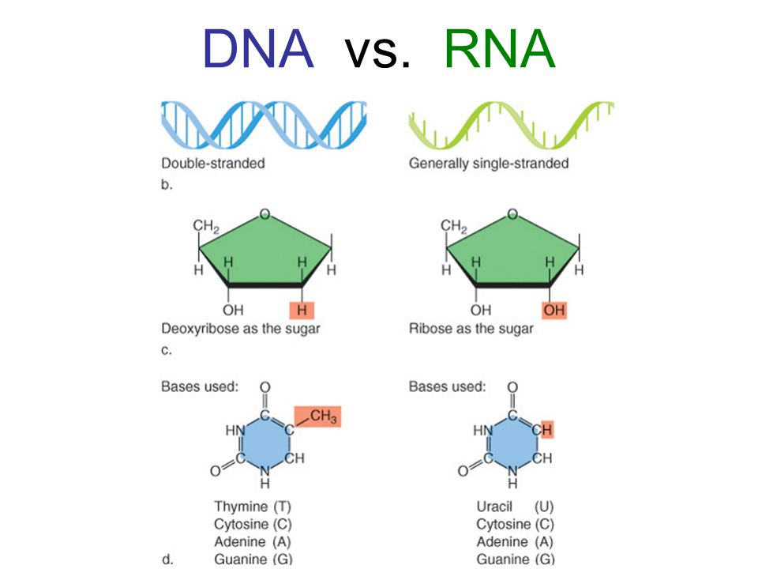

fot.3.

### Replikacja DNA

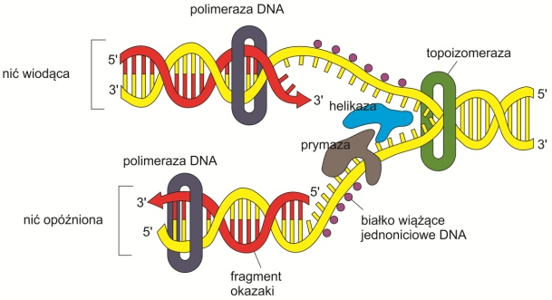

fot.4.

REPLIKACJA DNA JEST PROCESEM SEMIKONSERWATYWNYM.

**Replikacja semikonserwatywna** - sposób replikacji cząsteczki DNA; w nowej cząsteczce DNA (po replikacji) jedna nić pochodzi ze starej cząsteczki DNA, a druga (nowa) nić jest dobudowana na zasadzie komplementarności.

REPLIKACJA DNA

1. Białka SSB łącząc się do pojedynczych nici, Zapobiegają renaturacji
2. Helikaza łączy się z miejscem inicjacji i rozplata dwuniciową strukturę DNA
3. Primaza syntetyzuje starter RN
4. Polimeraza DNA syntetyzuje nową nić oraz sprawdza poprawność wbudowywanych nukleotydów, usuwając nieprawidłowe.
5. Nić wiodąca syntetyzowana jest w całości, w kierunku 5’utr do 3’utr
6. Nić opóźniona syntetyzowana jest w krótszych fragmentach (Okazaki), także w kierunku 5’ do 3’
7. Egzonukleaza wycina starter
8. Ligaza łączy powstałe fragmenty DNA

## Gen koduje białko

DNA -> transkrypcja -> mRNA -> translacja -> BIAŁKO

- transkrypcja - takie jakby tłumaczenie/odczytywanie DNA zachodzi w jądrze komórkowym
- translacja - dobudowanie biosynteza białka odbywa się w cytozolu za pomocą rybosomów

### Kod genetyczny

- Nienakładający się, bezprzecinkowy
- Niemalże uniwersalny
- Zdegenerowany
- Kodon start : AUG
- Stop kodony : UAA, UAG, UGA

### Nazewnictwo

- Gen to podstawowa jednostka dziedziczenia, która determinuje powstanie białka, zapisana w sekwencji nukleotydów
- Allel - odmiana genu
- Locus - miejsce, w którym zlokalizowany jest gen na chromosomie
- Genotyp - zespół genów odpowiedzialnych za fenotyp danego osobnika
- Fenotyp - zbiór cech danego osobnika

### Mutacja

Jest to zmiana w sekwencji nukleotydów w materiale genetycznym organizmu/komórki.

**Mutacje indukowane** to takie mutacje spowodowane działaniem czynników fizycznych lub chemicznych. **Mutacje letalne** to mutacje śmiertelne.

Mutacje to min:

- substytucje
- mutacja zmiany sensu – zamiana pary nukleotydów np. TA na AT
- mutacja nonsensowna – kodon zamieniany przemienia się w kodon STOP przez co jest zahamowana dalsza produkcja białka
- zmiana ramki odczytu
- delecja powodująca utratę sensu sekwencji
- delecja powoduje zamianę sekwencji aminokwasów
- delecje – usunięcie nukleotydu
- insercje (w tym duplikacje)
- mutacja silent- potencjalnie nie zmienia białka, jeżeli wystąpi w konkretnym miejscu nie zmieni DNA, ale może zmienić RNA

Sekwencja prawidłowa THE ONE BIG FLY HAD ONE RED EYE

Mutacja zmiany sensu THQ ONE BIG FLY HAD ONE RED EYE

Mutacja nonsensowna THE ONE BIG ***

Przesunięcie ramki odczytu THE ONE QBI GFL YHA DON ERE DEY

Delecja THE ONE BIG HAD ONE RED EYE

Insercja THE ONE BIG WET FLY HAD ONE RED EYE

Duplikacja THE ONE BIG FLY FLY HAD ONE RED EYE

#### Mutacje mogą być chromosomowe lub genowe.

Przy mutacjach chromosomowych wyróżniamy:

Mutacje somatyczne - powstają w komórkach somatycznych. Z punktu widzenia ewolucji nieistotne. Maja znaczenie biologiczne jeśli powodowany przez nie fenotyp jest szkodliwy dla zdrowia organizmu – mogą inicjować tworzenie nowotworu.

Mutacje generatywne - powstają w gametach, mogą być przekazywane potomstwu, pozostają bez wpływu na fenotyp w którym wystąpiły. Mają znaczenie w ewolucji genomu

Mutacje somatyczne oraz mutacje letalne nie są przekazywane z pokolenia na pokolenie

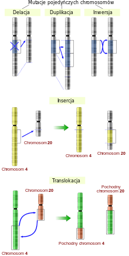

fot.5.

## Genetyka klasyczna

#### Grzegorz Mendel

1. Pierwsze prawo Mendla - prawo o segregacji gamet

W czasie tworzenia gamet każda para alleli ulega segregacji, a gameta przenosi tylko jeden allel danego genu.

2. Drugie prawo Mendla

Geny należące do różnych par alleli dziedziczą się niezależnie i są przekazywane do gamet oddzielnie, na zasadzie segregacji losowej.

Mendel udowodnił , że dziedziczenie cech grochu oparte jest na zestawie praw (które później zostały nazwane od jego nazwiska prawami Mendla). Podzielił cechy na cechy **recesywne** oraz **dominujące**.

*Dominacja częściowa* - współdziałanie genów allelicznych = np. biały+czerwony->różowy

*Kodominacja* - występowanie dwóch alleli danego genu z których żaden nie jest ani dominujący ani recesywny. Grupy krwi (AA, AB, BB)

*Fenomen bombajski* - występowanie grupy krwi 0 (układ AB0) u osób mających geny odpowiedzialne za powstawanie grup A i B. Z powodu obecności regularnych przeciwciał anty-A, anty-B oraz anty-H ludzie z fenotypem Bombay nie mogą być biorcami krwi innej niż o fenotypie Bombay. Z powodu rzadkości występowania może to stanowić problem w sytuacji wymagającej przetoczenia krwi u tych pacjentów.

*Penetracja* - procentowa częstość z jaką przejawia się gen dominujący lub recesywny

*Ekspresywność* - stopień fenotypowego przejawiania się genu

## Choroby genetyczne

### Chromosomopatie - choroby wywołane aberracjami chromosomowymi

**Trisomie**

- Chromosom 21 - Zespół Downa
- Chromosom 18 - Zespół Edwardsa
- Chromosom 13 - Zespół Patau

#### Zespół Downa

Częstotliwość występowania rośnie wraz z wiekiem matki.

- niepełnoprawność intelektualna
- mongoloidalne ustawienie szpar powiekowych
- zmarszczka nakątna
- dysplastyczne uszy
- wystający, duży język
- płaska potylica

Translokacyjny Zespół Downa - Nadmiar materiału genetycznego chromosomu 21. W takim przypadku długie ramię chromosomu 21 jest przyłączone do innego chromosomu, często jest to chromosom 14 albo pozostaje przyłączony do chromosomu 21. Prawidłowy podział mejotyczny prowadzący do powstania gamet obarczony jest wówczas znacznym ryzykiem powstania aneuploidalnych komórek płciowych.

#### Zespół Edwardsa

[figure not shown]

fot.10.

#### Zespół Patau

- większość płodów ulega poronieniu
- około 50% dzieci z zespołem Patauumiera w ciągu pierwszego miesiąca życia
- wady OUN – holoprosencefalia (brak podziału przodomózgowia na półkule)
- rozszczepienie wargi i podniebienia
- dysplastyczne uszy
- zmarszczka nakątna
- wady narządów wewnętrznych

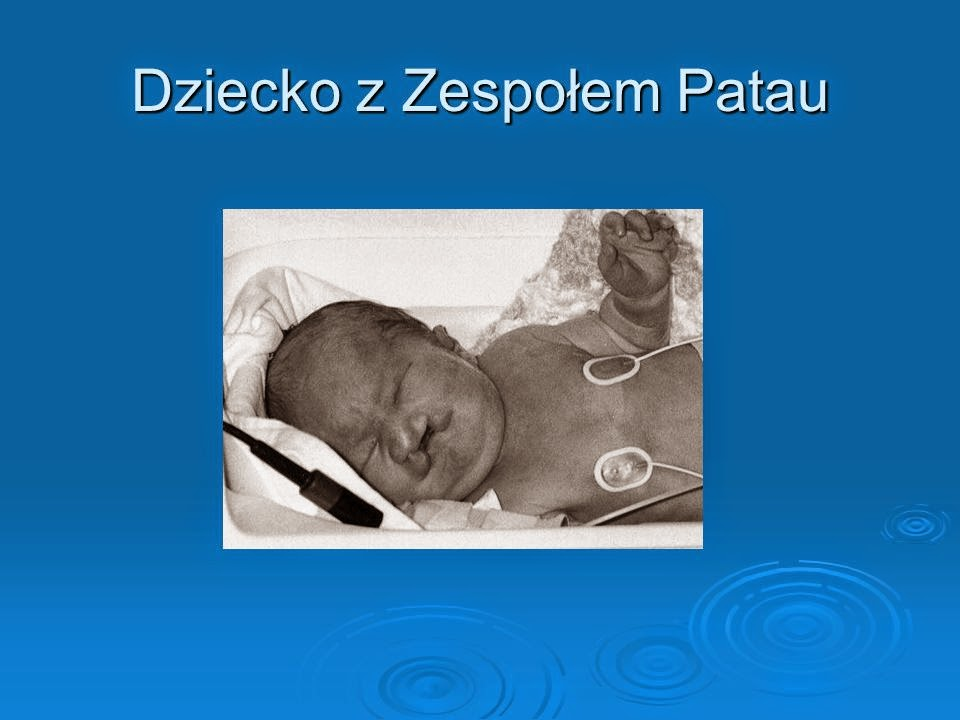

fot

#### Zespół Cri du chat

- około 75% chorych z zespołem Cri du chat umiera w pierwszych miesiącach życia, a około 90% - przed ukończeniem 1-go roku życia
- częściej rodzą się dziewczynki
- częściowa monosomia chromosomu 5)
- płacz przypominający miauczenie kota
- małogłowie
- znaczne opóźnienie rozwoju ruchowego i umysłowego

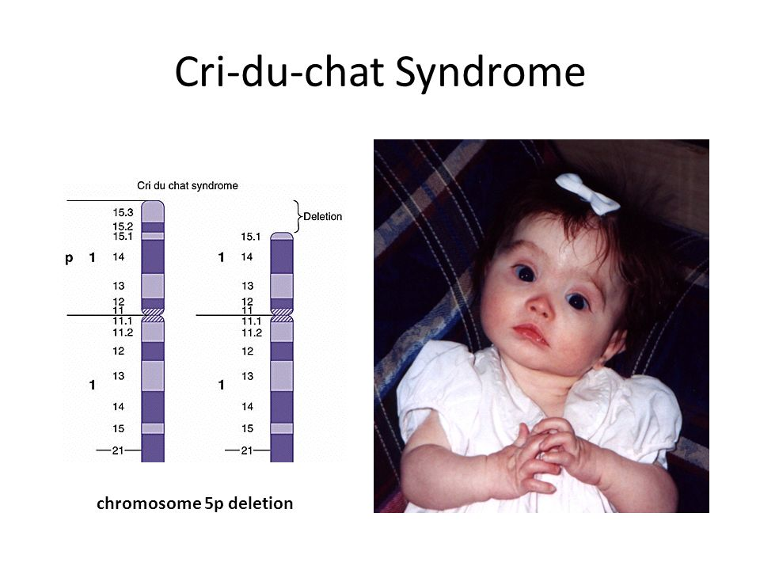

fot

#### Zespół Turnera

- Dziewczynki
- Rozwój psychiczny prawidłowy
- niski wzrost (do 145 cm.) przy zachowaniu proporcji (jeśli brak terapii hormonem wzrostu)
- płetwiasta szyja
- szeroko rozstawione gruczoły sutkowe
- niedorozwój wtórnych cech płciowych
- Utrata genów z ramion p chromosomu X (45,X)

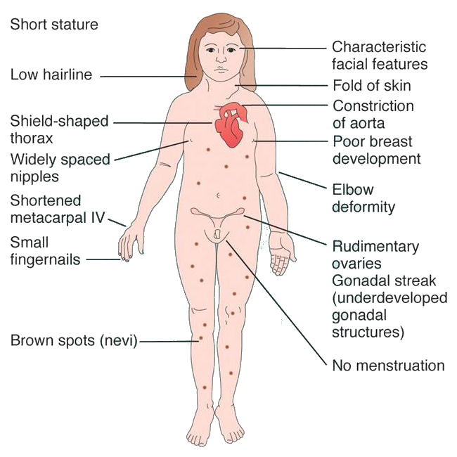

fot

#### Zespół Klinefeltera

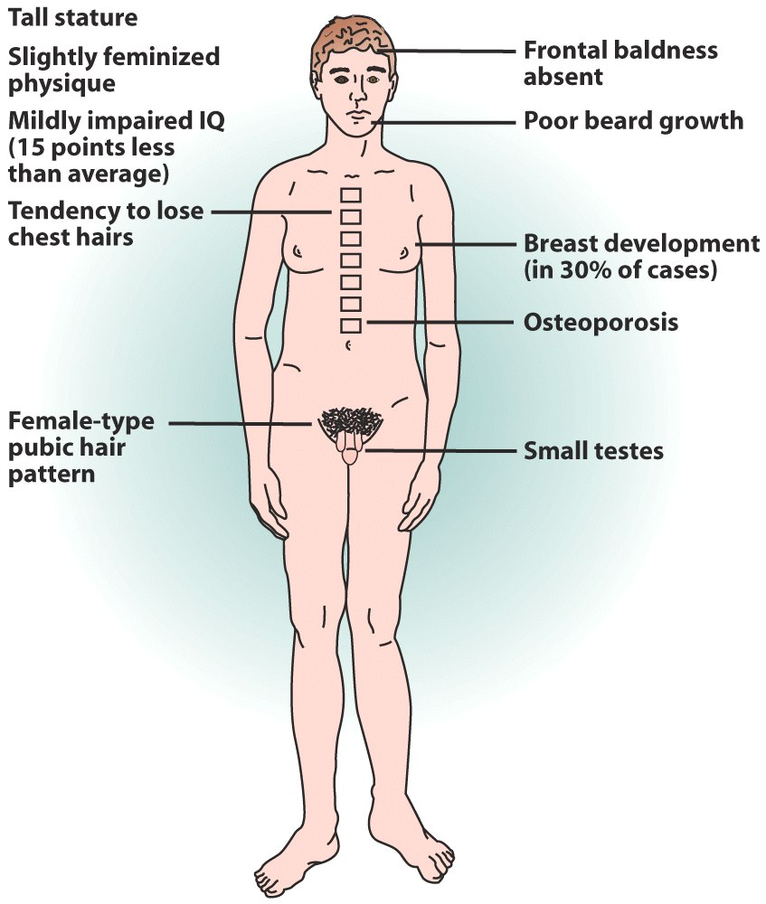

fot

#### 47, XYY

- brak objawów somatycznych
- wysoki wzrost i prawidłowa budowa ciała
- nie są to mężczyźni o większej agresji
- płodni

#### 47, XXX

- 1/1000 urodzeń dziewczynek
- brak objawów somatycznych
- u niektórych wtórny brak miesiączki i przedwczesna menopauza
- łatwiej zapadają na choroby psychiczne
- 75% płodnych

### Pozostałe

#### Mukowiscydoza

- Wrodzona, genetycznie uwarunkowana choroba ogólnoustrojowa.
- Najczęściej występująca u ludzi choroba genetyczna (średnio 1 na 2500 żywych urodzeń).
- Dziedziczona jest w sposób autosomalny recesywny.
- Przyczyną jest mutacja genu odpowiedzialnego za syntezę błonowego kanału chlorkowego CFTR (cystic fibrosis transmembrane conductance regulator)
- Nieprawidłowy transport, jonów chlorkowych sprawia, że na zewnątrz komórek odczyn zmienia się na bardziej kwaśny, co prowadzi do zaburzeń funkcji komórek nabłonkowych.
- Na przykład nieszkodliwe w normalnych warunkach substancje występujące w śluzie, zwane mucynami, w kwaśnym środowisku wytrącają się powodując, że wydzielany przez różne gruczoły śluz staje się gęsty.
- Zaburza to pracę narządów posiadających gruczoły śluzowe (płuca, oskrzela, trzustka).

#### Choroba Huntingtona

- Autosomalna dominujaca
- Powolna degeneracja komórek nerwowych mózgu, wyniszczenie organizmu, ewentualna śmierć po 15-20 latach od momentu ujawnienia się choroby
- Objawy: ruchowe - skurcze mięśni, tiki nerwowe, sztywność, zaburzenia równowagi, trudności w wymowie, trudności z przełykaniem pokarmów, zmiany osobowości, apatia, uczucie niepokoju, nerwowość, obsesje, majaczenia, manie prześladowcze i wewnętrzne przekonanie iż jest się zdrowym
- Allel z premutacją - 30 powtórzeń CAG
- 36 do 180 powtórzeń CAG w allelu zmutownym
- Wiek, w którym pojawiają się pierwsze objawy choroby pozostaje w ścisłej korelacji z ilością powtórzeń CAG
- Ludzki gen Hdh (chromosom 4) zawiera sekwencje 5’-CAG-3’ powtórzoną kolejno od 10 do 35 razy, która w produkcie białkowym koduje serię glutamin.
- W chorobie Huntingtona liczba tych powtórzeń zwiększa się do 36-121 razy co zwiększa długość traktu poliglutaminowego i powoduje powstanie nieprawidłowo funkcjonującego białka.

#### Zespoł łamliwego chromosomu X

- Objawy chorobowe wśród mężczyzn: IQ od 20 do 60, odróżniająca budowa ciała, wystające uszy, duże jądra, nadaktywność lub autyzm
- Objawy chorobowe wśród kobiet: opóźnienie w rozwoju umysłowym (połowa ma normalne IQ)
- Mutacja w genie FMR1 położonym na chromosomie X.
- Białko FMRP, kodowane przez gen FMR1 jest niezbędne do prawidłowego rozwoju synaps między neuronami odpowiedzialnymi m.in. za procesy uczenia się i zapamiętywania. Jego brak powoduje opóźnienie dojrzewania neuronów

#### Dysforia miotoniczna

- Postępująca słabość mięśni, zwłaszcza mięśni twarzy, mięśni mostkowo-sutkowych, dystalnych mięśni kończyn
- norma 5 – 37 powtórzeń CTG, u osób chorych 50 – 3000 powtórzeń CTG

#### Niepełnosprawność intelektualna

- Grupa schorzeń rozwojowych charakteryzująca się istotnie zaburzonymi zdolnościami poznawczymi prowadzącymi do ograniczeń w zakresie uczenia się, zachowań adaptacyjnych i umiejętności praktycznych.
- Pacjenci mają istotnie niższy od przeciętnego ogólny poziom funkcjonowania intelektualnego występujący łącznie z deficytem w zakresie zachowań adaptacyjnych (w szczególności niezależności i odpowiedzialności)
- Ograniczenie w funkcjonowaniu intelektualnym oraz przystosowaniu społecznym.
- Zaburzenie rozwojowe – ujawnia się przed 18rż. zwykle współwystępuje opóźnienie rozwoju motorycznego

#### Zaburzenia kręgu autyzmu (ASD)

**Spektrum autystyczne** – szerokie pojęcie, obejmujące różne typy osób o cechach autystycznych, wykazujących odmienne mechanizmy lub przyczyny powodujące trudności rozwojowe i mające często odrębne wymagania wobec środowiska. Wszystkie one charakteryzują się znacznymi zaburzeniami interakcji społecznych i komunikacji, jak również znacznie ograniczonymi zainteresowaniami i bardzo powtarzalnym zachowaniem.

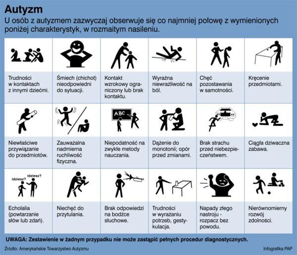

fot.9

#### Anemia sierpowata

- wrodzona choroba krwi
- nieprawidłowa budowa hemoglobiny, która nie tylko słabo wiąże cząsteczki tlenu, lecz także przyczynia się do deformacji czerwonych krwinek (zamiast kształtu dysku przybierają kształt półksiężyców - sierpowaty).
- mała przeżywalność czerwonych krwinek (zamiast ok 100 przeżywają ok kilkunastu dni)
- szpik nie nadąża z wytwarzaniem nowych krwinek, co jest przyczyną anemii
- chorzy są oporni na malarię